# R Notebook

scRNAseq data from MBO 160 AST23 and AST23 isogenic control Organoids were grown in shaking cultures, dissocation was performed manually and with TryPLE. The live cells were sorted by FACS and 3000 cells were targeted for sequencing.  
Each dissociated was a pool of three MBOs. Each lane in 10X controler was loaded with a genotype. Filter, cluster and annotate clusters

Prepare the work space

```r
# clear space
# load libraries

rm(list=ls())
library("ggplot2")
library("Seurat")
library("cowplot")
library("clustree")
library(patchwork)
library(dplyr)
library("Matrix")
library("SingleCellExperiment")
```

Read in the raw data and create the seurat objects

```r
#### Read in data

# AST23
pathway1 <- "/home/rhalena/scRNAseq/AST23_160dMBO_Feb2020/AST23/raw_feature_bc_matrix"

# AST23 isogenic
pathway2 <- "/home/rhalena/scRNAseq/AST23_160dMBO_Feb2020/AST23isogenic/raw_feature_bc_matrix"
AST23.data <- Read10X(data.dir = pathway1)
AST23 <- CreateSeuratObject(counts = AST23.data, project = "AST23")
# min filter so that calculating MT won't crash
AST23 <- subset(AST23, subset = nFeature_RNA > 1)
AST23[["percent.mt"]] <- PercentageFeatureSet(AST23, pattern = "^MT-")
AST23
```

```
An object of class Seurat
33538 features across 130553 samples within 1 assay
Active assay: RNA (33538 features, 0 variable features)
```

```r
AST23iso.data <- Read10X(data.dir = pathway2)
AST23iso <- CreateSeuratObject(counts = AST23iso.data, project = "Isogenic")
# min filter so that calculating MT won't crash
AST23iso <- subset(AST23iso, subset = nFeature_RNA > 1)
AST23iso[["percent.mt"]] <- PercentageFeatureSet(AST23iso, pattern = "^MT-")
AST23iso
```

```
An object of class Seurat
33538 features across 158057 samples within 1 assay
Active assay: RNA (33538 features, 0 variable features)
```

Filter conditions were previously compared and optimal filters selected here.

```r
# Filter with 500 and less than 20% mitochondria
AST23f <- subset(AST23, subset = nFeature_RNA > 500 & percent.mt < 20)
AST23f
```

```
An object of class Seurat
33538 features across 1193 samples within 1 assay
Active assay: RNA (33538 features, 0 variable features)
```

```r
AST23isof <- subset(AST23iso, subset = nFeature_RNA > 500 & percent.mt < 20)
AST23isof
```

```
An object of class Seurat
33538 features across 2938 samples within 1 assay
Active assay: RNA (33538 features, 0 variable features)
```

```r
MBO <- merge(AST23f, y=AST23isof, add.cell.ids = c("AST23","Isogenic"))
MBO
```

```
An object of class Seurat
33538 features across 4131 samples within 1 assay
Active assay: RNA (33538 features, 0 variable features)
```

Align data from two samples

```r
MBO.anchors <- FindIntegrationAnchors(object.list = MBO.list, anchor.features = features)
```

```
Scaling features for provided objects
```

```
  |                                                  | 0 % ~calculating
  |+++++++++++++++++++++++++                         | 50% ~01s
  |++++++++++++++++++++++++++++++++++++++++++++++++++| 100% elapsed=02s
```

```
Finding all pairwise anchors
```

```
  |                                                  | 0 % ~calculating
```

```
Running CCA
Merging objects
Finding neighborhoods
```

```
Finding anchors
    Found 4336 anchors
Filtering anchors
```

```
    Retained 3180 anchors
```

```
  |++++++++++++++++++++++++++++++++++++++++++++++++++| 100% elapsed=37s
```

```r
# create a slot with the integration assay in a seurat object
MBO.combined <- IntegrateData(anchorset = MBO.anchors)
```

```
Merging dataset 1 into 2
Extracting anchors for merged samples
Finding integration vectors
Finding integration vector weights
```

```
Integrating data
```

Perform the integrated analysis - clustering

```r
MBO.combined <- FindClusters(MBO.combined, resolution = c(0,0.1,0.3,0.6,0.9,1.2,1.8))
```

```
Modularity Optimizer version 1.3.0 by Ludo Waltman and Nees Jan van Eck

Number of nodes: 4131
Number of edges: 427577

Running Louvain algorithm...
```

```
Maximum modularity in 10 random starts: 1.0000
Number of communities: 1
Elapsed time: 0 seconds
Modularity Optimizer version 1.3.0 by Ludo Waltman and Nees Jan van Eck

Number of nodes: 4131
Number of edges: 427577

Running Louvain algorithm...
```

```
Maximum modularity in 10 random starts: 0.9426
Number of communities: 3
Elapsed time: 0 seconds
Modularity Optimizer version 1.3.0 by Ludo Waltman and Nees Jan van Eck

Number of nodes: 4131
Number of edges: 427577

Running Louvain algorithm...
```

```
Maximum modularity in 10 random starts: 0.8928
Number of communities: 8
Elapsed time: 0 seconds
Modularity Optimizer version 1.3.0 by Ludo Waltman and Nees Jan van Eck

Number of nodes: 4131
Number of edges: 427577

Running Louvain algorithm...
```

```
Maximum modularity in 10 random starts: 0.8477
Number of communities: 9
Elapsed time: 0 seconds
Modularity Optimizer version 1.3.0 by Ludo Waltman and Nees Jan van Eck

Number of nodes: 4131
Number of edges: 427577

Running Louvain algorithm...
```

```
Maximum modularity in 10 random starts: 0.8134
Number of communities: 11
Elapsed time: 0 seconds
Modularity Optimizer version 1.3.0 by Ludo Waltman and Nees Jan van Eck

Number of nodes: 4131
Number of edges: 427577

Running Louvain algorithm...
```

```
Maximum modularity in 10 random starts: 0.7856
Number of communities: 14
Elapsed time: 0 seconds
Modularity Optimizer version 1.3.0 by Ludo Waltman and Nees Jan van Eck

Number of nodes: 4131
Number of edges: 427577

Running Louvain algorithm...
```

```
Maximum modularity in 10 random starts: 0.7366
Number of communities: 15
Elapsed time: 0 seconds
```

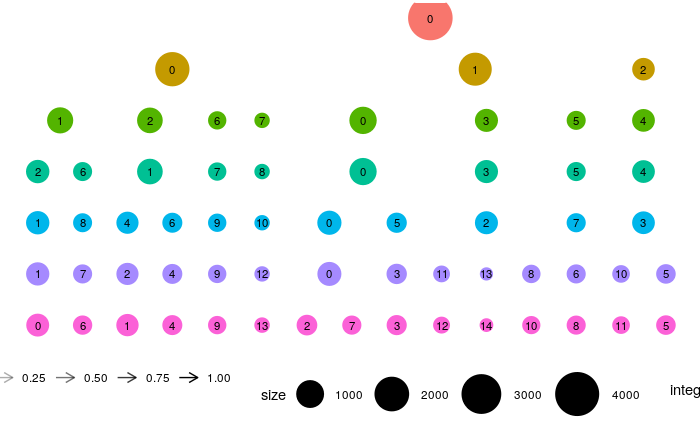

```r
clustree(MBO.combined, prefix = "integrated_snn_res.") + theme(legend.position = "bottom")
```

Visualize the results

[figure not shown]

```r
# save this object for future reference
# filter > 500 nRNA and < 20% mt DNA
# integrated object
saveRDS(MBO.combined,file = "CombinedIntegratedAST23CON_21-07-2021.rds")

MBO.combined <- readRDS("CombinedIntegratedAST23CON_21-07-2021.rds")
```

Identify cell types/ annotate clusters Using Seurat Identify markers in an R script for each resolution. Performed separately as this step is long.

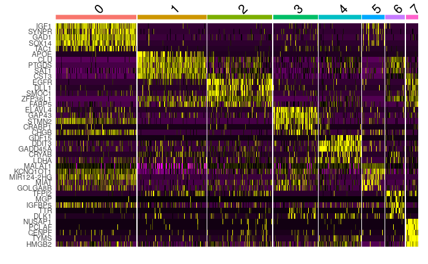

Look at a list of known markers

I have created heatmaps of the known markers for each resolution together with the find markers function in a separate script. See ‘getclustermarkers.R’

[figure not shown]

```r
# stem cells, neurons, glia, epithelia/endothelial cells

feature_list = c("DLX2","SOX2","PAX6","SOX9","HES1","ITGA6","MAP2","NCAM1","CD24","GRIA2","GRIN2B","GABBR1","TH","CORIN","CALB1","KCNJ6","CXCR4","ITGA6","NES","SLC1A3","CD44","AQP4","S100B","GFAP","ALDH1L1","SLC1A3","SLC1A2", "PDGFRA","CLDN11","VIM","VCAM1")


DoHeatmap(MBO.combined, group.by = "integrated_snn_res.0.3", features = feature_list)
```

Look at expression of cell type gene list

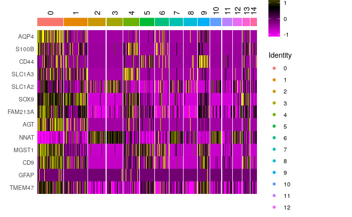

```r
astrocyte <-  c("AQP4","S100B","CD44","SLC1A3","SLC1A2","SOX9","FAM213A", "AGT","NNAT","MGST1","CD9","GFAP","TMEM47")
# note SLC1A3 is EAAT1 and SCL1A2 is EAAT2
DoHeatmap(MBO.combined, features = astrocyte, size=4, angle =90, group.bar.height = 0.05)
```

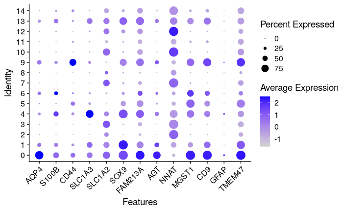

```r
DotPlot(MBO.combined, features = astrocyte) + RotatedAxis()
```

Check cluster labels with automated annotation using two methods: I’m selecting from a long list of options for ones that were Marker gene database-based : scCATCH ,, SCINA Correlation-based (with reference scRNA data): Garnett, scClassify, scID, SingleR ClustifyR - can use any database including other scRNAseq

```r
clu_markers <- findmarkergenes(MBO.combined, species = "Human")
```

```
Note: the raw data matrix includes 4131 cells and 33538 genes.

---Revising gene symbols according to NCBI Gene symbols (updated in June 19, 2020, https://www.ncbi.nlm.nih.gov/gene) and no matched genes and duplicated genes will be removed.

Note: the new data matrix includes 4131 cells and 23321 genes.
Note: There are 15 clusters in Seurat object.
Preparing to find potential marker genes for All cluster(s).
Finding potential marker genes for cluster 0
```

[output not shown]

[output cut: 283 more lines]

[output not shown]

```
---Done---
Finding potential marker genes for cluster 1
```

[output not shown]

[output cut: 263 more lines]

[output not shown]

```
---Done---
Finding potential marker genes for cluster 2
```

[output not shown]

[output cut: 238 more lines]

[output not shown]

```
---Done---
Finding potential marker genes for cluster 3
```

[output not shown]

[output cut: 319 more lines]

[output not shown]

```
---Done---
Finding potential marker genes for cluster 4
```

[output not shown]

[output cut: 305 more lines]

[output not shown]

```
---Done---
Finding potential marker genes for cluster 5
```

[output not shown]

[output cut: 324 more lines]

[output not shown]

```
---Done---
Finding potential marker genes for cluster 6
```

[output not shown]

[output cut: 155 more lines]

[output not shown]

```
---Done---
Finding potential marker genes for cluster 7
```

[output not shown]

[output cut: 259 more lines]

[output not shown]

```
---Done---
Finding potential marker genes for cluster 8
```

[output not shown]

[output cut: 173 more lines]

[output not shown]

```
---Done---
Finding potential marker genes for cluster 9
```

[output not shown]

[output cut: 267 more lines]

[output not shown]

```
---Done---
Finding potential marker genes for cluster 10
```

[output not shown]

[output cut: 301 more lines]

[output not shown]

```
---Done---
Finding potential marker genes for cluster 11
```

[output not shown]

[output cut: 216 more lines]

[output not shown]

```
---Done---
Finding potential marker genes for cluster 12
```

[output not shown]

[output cut: 323 more lines]

[output not shown]

```
---Done---
Finding potential marker genes for cluster 13
```

[output not shown]

[output cut: 250 more lines]

[output not shown]

```
---Done---
Finding potential marker genes for cluster 14
```

[output not shown]

[output cut: 288 more lines]

[output not shown]

```
---Done---
```

```r
# now use the marker found with scCATCH to annotate cluster
clu_ann <- scCATCH(object = clu_markers$clu_markers, species = 'Human', tissue = 'Brain')
```

```
Note: there are 693 potential marker genes in CellMatch database for Human on Brain!
Note: there are 37 cell types in CellMatch database for Human on Brain!
Beginning evidence-based scoring and annotation
```

[output not shown]

```
---Done---
```

```r
# this only takes a few minutes to run
```

Using scCATCH there are astrocytes and oligodendrocytes and some neurons.

```r
# now use the marker found with scCATCH to annotate cluster
clu_ann <- scCATCH(object = clu_markers$clu_markers, species = 'Human', tissue = c("Brain","Midbrain","Fetal brain","Embryonic brain","Sympathetic ganglion"))
```

```
Note: there are 701 potential marker genes in CellMatch database for Human on Brain, Midbrain, Fetal brain, Embryonic brain, Sympathetic ganglion!
Note: there are 39 cell types in CellMatch database for Human on Brain, Midbrain, Fetal brain, Embryonic brain, Sympathetic ganglion!
Beginning evidence-based scoring and annotation
```

[output not shown]

```
---Done---
```

Clusters are astrocyte, oligodendrocyte neurons and unknown.

```r
clu_ann
```

| cluster | cluster_marker | cell_type | celltype_score | celltype_related_marker | PMID |
| --- | --- | --- | --- | --- | --- |
| 0 | ADH5, AGT, ALDH2, ANKRD29, ANKRD6, ANOS1, APOE, AQP4, ARHGAP5, ARL6IP5, ASAH1, ATP1B2, B2M, BAG3, BCAN, BCAP29, C3orf70, CA14, CALU, CBR1, CD81, CD9, CDH6, CEBPD, CHPT1, CLU, CNN3, COLGALT2, CPNE8, CS… | Astrocyte | 0.79 | AGT, APOE, ATP1B2, CLU, CST3, DKK3, EZR, HEY1, HLA-E, LIX1, METTL7A, NTRK2, AQP4, SLC4A4 | 27806376, 26060301 |
| 1 | ABCA5, ASCL1, CXCR4, DLL1, EGFR, JAG1, KCNJ6, LRRN1, MEST, NFIA, PCDH18, PCDH19, PLAGL1, POU3F2, RNF180, SMOC1, TEAD1, TMEM158, TNC, TRBC2, ZFP36L1 | Astrocyte | 0.67 | NFIA, ZFP36L1 | 26295203, 27806376 |
| 3 | AKAP12, AMER2, AMPH, APC, ARHGEF12, ARID1B, ARL6IP1, ASXL3, ATP8A2, BACH2, BCL11A, CA10, CADPS, CCDC88A, CCSAP, CCSER1, CDH10, CDH8, CELF2, CHL1, CHRM2, CNKSR3, CNTNAP2, DCX, DIRC3, DLG1, DMBX1, DOCK4… | Lake Et Al.science.ex6 | 0.61 | LRRC3B, TSPAN18, ZNF385D | 27339989 |
| 4 | EDNRB, FABP5, FGFBP3, GLUL, GPM6B, ITGB8, OLIG1, RBP1, SLC1A3, SLIT1, SRI, UBL3 | Astrocyte | 0.61 | EDNRB, GLUL, SLC1A3 | 27806376 |
| 5 | AK6, ANAPC16, ANXA2, ATF5, BNIP3, CCPG1, CD55, CEBPB, CLGN, CNIH4, CRYAB, DDIT3, DDIT4, EGLN3, ENO1, ERO1A, FTL, GBE1, GDF15, GHITM, HSPA5, HSPA9, HSPB1, LDHA, LGALS3, LYRM1, METTL23, MIR22HG, MKNK2, … | Astrocyte | 0.58 | CRYAB, EGLN3 | 27806376 |
| 6 | COX4I1, COX6C, COX7C, RPL32, RPL39, RPL41, RPLP1, RPS24, RPS26, RPS3A, TMA7, UQCR10 | Oligodendrocyte | 0.5 | COX7C | 27806376 |
| 7 | AKAP7, BTG1, C21orf91, CRHBP, EMX2, KLHL5, MAB21L1, PDS5B, TOX3 | NA | NA | NA | NA |
| 8 | LUC7L3, MALAT1, N4BP2L2 | NA | NA | NA | NA |
| 9 | ABCA8, ADAMTS9, ATRAID, CD164, CD44, CFC1, CKAP4, COL21A1, COL4A6, DCN, DIPK2A, ECEL1, FOXA1, FSTL1, GNG11, GRIN2A, ID3, IFITM3, IFT57, KCNJ16, KCNMB1, LGI1, LMO2, MATN2, MORN2, MSX1, MT1X, OSTC, PAPS… | Astrocyte, Lake Et Al.science.ex4, Neuron | 0.5, 0.5, 0.5 | MT1X, DCN, PAPSS2 | 27806376, 26060301, 27339989 |
| 10 | ANK2, ATP1A3, BASP1, BRINP1, CADM1, CALY, CDKN2D, CNTN1, CREG2, DNAJC6, DPYSL2, EDIL3, EPHA5, FAM216A, FGF12, FGF13, GABRA1, GABRA2, GABRB2, GAP43, GPRIN3, JAZF1, KIF5C, KLC1, LONRF2, LUZP2, MAP6, MGA… | Oligodendrocyte | 0.58 | GAP43, PLPPR1 | 27806376 |

[output cut: 4 more lines]

```r
NA
```

ClustifyR

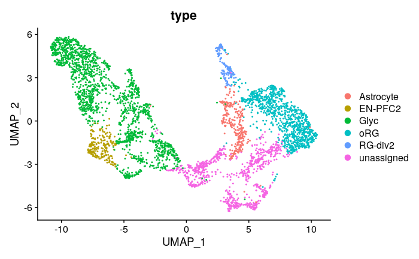

There is one cluster assigned as astrocytes. There are two groups of radial glia, a dividing group and oRG (outer radial glia) The neurons are assigned as Glyc (cell undergoing glycolysis) and EN-PFC2 (Early and Late Born Excitatory Neurons) Some of the glia and the other cells that could be epithelial and endothelial cells are not assigned. The is endothelial but not epithelial cells in the reference data.

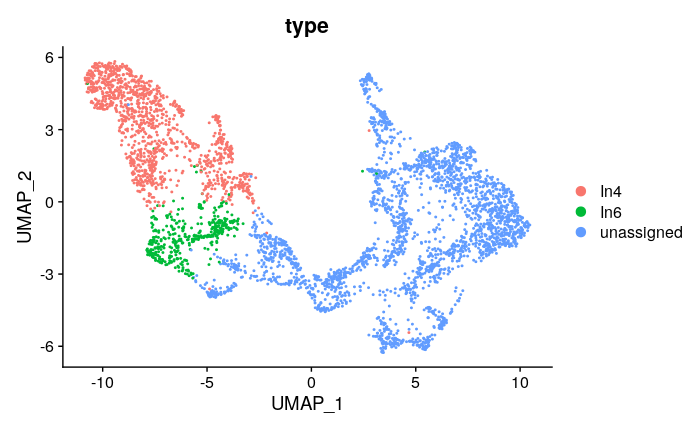

The neurons are all labeled as two subgroups of inhibitory neurons and all the other cells are unknown

```r
res.manno <- clustify( MBO.combined,
                 ref_mat = sce_ref_manno,
                 cluster_col = "seurat_clusters",
                 seurat_out = TRUE,
                 n_genes = 2000
)
```

```
object data retrieval complete, moving to similarity computation
using # of genes: 1753
similarity computation completed, matrix of 15 x 56, preparing output
using threshold of 0.58
```

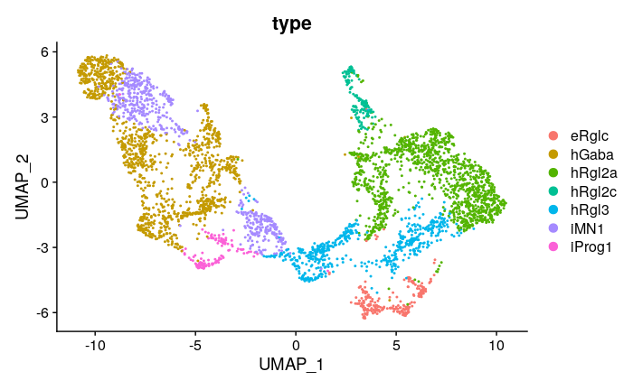

```r
DimPlot(res.manno, reduction = "umap", repel = TRUE, label = TRUE, group.by = "type")
```

With this dataset all the gila are assigned as different types of radial glia The neurons are all assigned as either neurons or neural progenitors although inhibitory.

Single R

```r
out[5:16, ]
```

```
DataFrame with 12 rows and 5 columns
                 Reference  Taxonomy                   Part    Number                   Call
               <character> <integer>            <character> <integer>            <character>
1     @baron2016singlecell     10090               pancreas      1886 BaronPancreasData('m..
2         @bhaduri2020cell      9606     cortical organoids    242349  BhaduriOrganoidData()
3   @buettner2015computa..     10090   embryonic stem cells       288      BuettnerESCData()
4   @bunis2021haematopoi..      9606 haematopoietic stem ..      5183        BunisHSPCData()
5   @campbell2017molecular     10090                  brain     21086    CampbellBrainData()
...                    ...       ...                    ...       ...                    ...
8         @ernst2019staged     10090                 testis     68937 ErnstSpermatogenesis..
9   @fletcher2017deconst..     10090   olfactory epithelium       616 FletcherOlfactoryDat..
10         @grun2016denovo     10090 haematopoietic stem ..      1915          GrunHSCData()
11         @grun2016denovo      9606               pancreas      1728     GrunPancreasData()
12   @giladi2018singlecell     10090 haematopoietic stem ..     81024 GiladiHSCData(mode='..
```

Using Single R - from The SingleR book

```r
#library("SingleR")
# reference loaded above
# Seurat object already created
# I need to use the normalized counts matrix from the Seurat object
DefaultAssay(MBO.combined) <- "RNA"
MBO.combined <- NormalizeData(MBO.combined, normalization.method = "LogNormalize")
MBO.combined <- ScaleData(MBO.combined)
mnc <- GetAssayData(MBO.combined, slot = "scale.data")
```

```r
library(SingleR)
# get the singleR preditions based on the reference data

# try with the human primary cell atlas
# single cell method
pred.MBO <- SingleR(test = mnc, ref = hpca.se, assay.type.test=1,
    labels = hpca.se$label.main)
```

```r
sr_ref_dev_brain
```

```
class: SingleCellExperiment
dim: 56864 4261
metadata(0):
assays(1): tpm
rownames(56864): DDC8 AC092057.1 ... AQP7 RPL19P20
rowData names(0):
colnames(4261): Hi_GW21_4.Hi_GW21_4 Hi_GW21_5.Hi_GW21_5 ... S222.H7 S222.H8
colData names(6): WGCNAcluster Name ... Laminae Area
reducedDimNames(5): tMinusSNE_on_WGCNA TriMap TMinusSNE_scanpy UMAP_scanpy PAGAPlusForceAtlas2_scanpy
mainExpName: NULL
altExpNames(0):
```

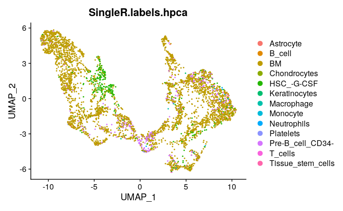

```r
# add Single cell labels into Seurat

MBO.combined[["SingleR.labels.hpca"]] <-pred.MBO$labels

DimPlot(MBO.combined, reduction = "umap", repel = TRUE, label = TRUE, group.by = "SingleR.labels.hpca")
```

```r
pred.MBO.c <- SingleR(test = mnc, ref = hpca.se, clusters = MBO.combined@meta.data$seurat_clusters, assay.type.test=1,
    labels = hpca.se$label.main)



pred.MBO.c@listData$labels
```

```
 [1] "Astrocyte"        "Astrocyte"        "T_cells"          "Platelets"        "Astrocyte"        "Epithelial_cells"
 [7] "BM"               "B_cell"           "HSC_-G-CSF"       "Chondrocytes"     "Neurons"          "Keratinocytes"
[13] "T_cells"          "Astrocyte"        "B_cell"
```

```r
# Summarizing the distribution:
table.pred.MBO.c <- table(pred.MBO.c$labels)
```

The cluster indexes are given above - astrocytes and neurons all match with expected clusters. The other cell types do not make sense. The epithelial cell group could be correct.

Look at expression of known cell type markers across clusters.

[figure not shown]

```
The following requested variables were not found: FAM60A, ME152, GLAST
```

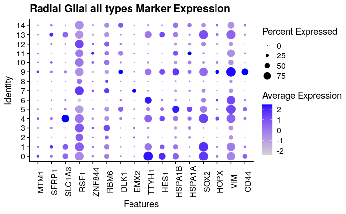

```r
RG <- c("FAM60A","MTM1","SFRP1","SLC1A3","RSF1","ZNF844","ME152","RBM6","DLK1","EMX2","TTYH1","HES1","HSPA1B","HSPA1A","SOX2","HOPX","GLAST","VIM","CD44")
# note SLC1A3 is GLAST
DotPlot(MBO.combined, features = RG) + theme(axis.text.x = element_text(angle = 90)) + ggtitle("Radial Glial all types Marker Expression")
```

```
The following features were omitted as they were not found in the scale.data slot for the RNA assay: GLAST, ME152, FAM60A
```

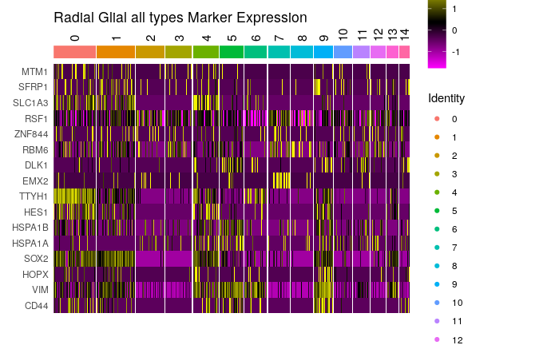

```r
DoHeatmap(MBO.combined, group.by = "seurat_clusters", features = RG, size=4, angle =90, group.bar.height = 0.05) + ggtitle("Radial Glial all types Marker Expression")
```

```r
# other cells

# endothelial Collagen IV
endothelial <- c("APOLD1","ITM2A","BSG","IFITM1","RSG5","")
microglia <- c("CCL4","CCL3","CTSS","TYROBP","CD83")

ependymal <- c("FOXJ1")
```

Name cluster - based on looking at top markers compared to expression databases UCSC, Single Cell Landscape and DEG published.

I will combine Cluster 2 and 3 - they are both more mature neurons that contain both excitatory and inhibitory neurons - they may be interesting later but for our purposes these can be merged. I will also merge 10 and 12 the two clusters containing the most DA marker expression.

I will not merge the Radial Glia because they are all different from each other.

Cluster annotation

0 Astroctye 1 RG-a 2 Neuron 3 Neuron 4 Astrocyte-i 5 Epithelial 6 Oligodendrocyte 7 Neuron-inh 8 Neuron-exc 9 RG-d1 10 Neuron-DA 11 Other 12 Neuron-DA 13 RG-d2 14 Neural Precursors

Rename clusters and look at expression plus markers

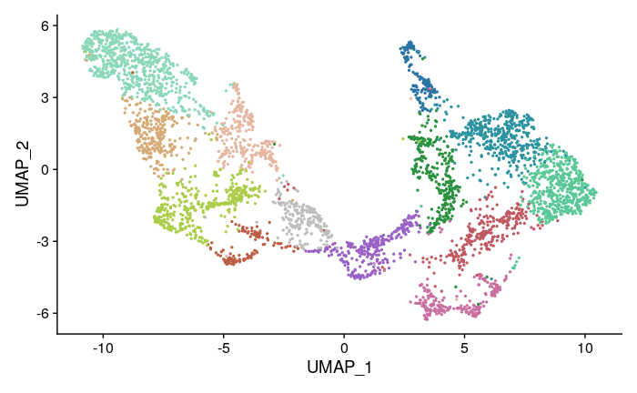

Compare AST23 to control

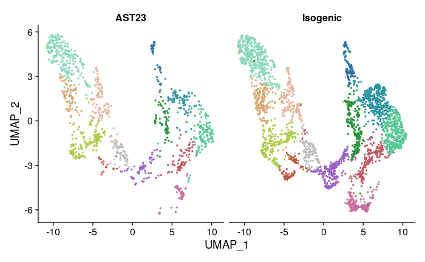

Proportion test to see in these to samples if the difference are significant. However for this test we can only consider this as n=1 replicate of proportions so we cannot make conclusions.

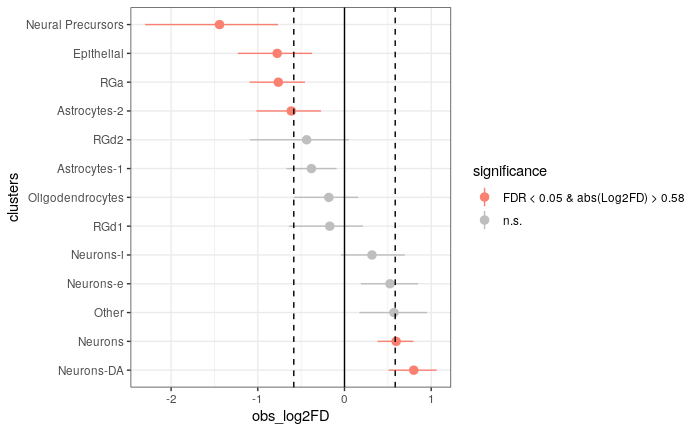

```r
library("scProportionTest")

# have a seurat object
# add the test
prop_test <- sc_utils(MBO.combined)

# Once the object is created, the permutation testing and bootstrapping can be run.
prop_test <- permutation_test(
    prop_test, cluster_identity = "cluster_labels",
    sample_1 = "Isogenic", sample_2 = "AST23",
    sample_identity = "orig.ident"
)

# A point-range plot of the results can then be created.

permutation_plot(prop_test)
```

```r
NA
NA
NA
```

Expression of TH

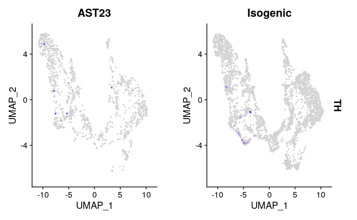

SNCA expression

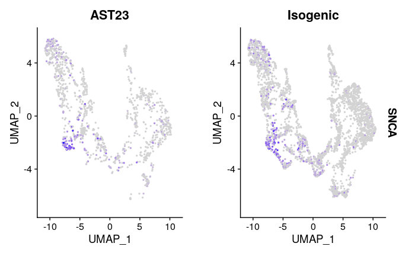

```r
markers3 <- c("AQP4", "CLU","APOE"   ,"DLL1", "ASCL1", "POU3F2"  ,"SYT1","STMN1","DCX"   , "EDNRB", "SLC1A3","ETV1" ,"DDIT3", "SQSTM1","ATF5"   ,"RPS24","RPL12", "FTH1"   ,"GAD1","GAD2", "RELN"  , "MALAT1", "LUC7L3", "GRIA2"  ,"ABCA8","GNG11","VIM", "STMN2", "SYT4", "NNAT","AFT3","BBC3","GADD45A"   ,"CENPF","CDK1","HMGB2"  ,"SCG2", "CALB1", "NRN1")

DoHeatmap(MBO.combined, features = markers3, angle = 90, group.colors = colours, size = 4)  + NoLegend()
```

```
The following features were omitted as they were not found in the scale.data slot for the RNA assay: AFT3
```

```r
tiff("HeatMap_clustermarkers_labelledCluster.tiff", units = "in", width = 6, height = 12, res=300)
```

```r
  DoHeatmap(MBO.combined, features = markers3, angle = 90, group.colors = colours, size = 4)  + NoLegend()
```

```
The following features were omitted as they were not found in the scale.data slot for the RNA assay: AFT3
```

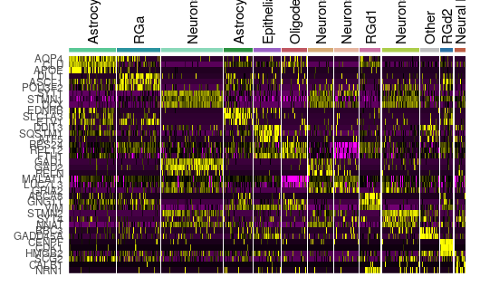

```r
dev.off()
```

Expression of dopaminergic markers

```
The following features were omitted as they were not found in the scale.data slot for the RNA assay: LIMX1A
```

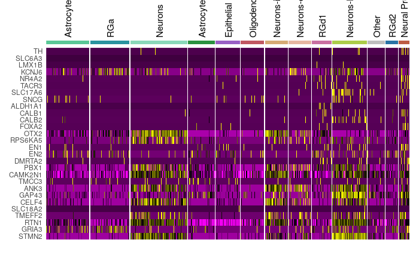

```r
DoHeatmap(MBO.combined, features = DaN, angle = 90, group.colors = colours, size = 4)  + NoLegend()
```

Reactive astrocytes Markers from scartin, Carole, et al. “Reactive astrocyte nomenclature, definitions, and future directions.” Nature neuroscience 24.3 (2021): 312-325.

```
The following requested variables were not found: NFAT, IL17R, SCL1A2, SCL1A3
```

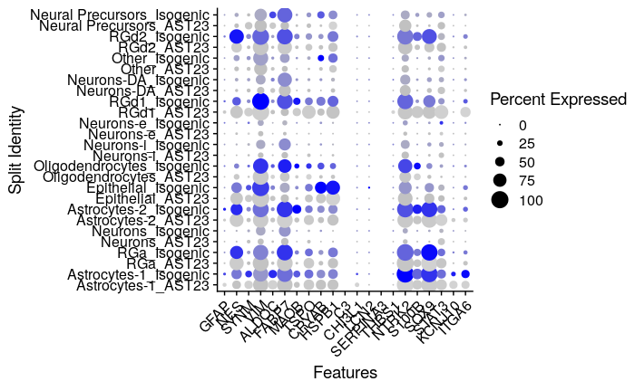

```r
DotPlot(MBO.combined, features = reac.astro, group.by = "cluster_labels", split.by = "orig.ident") + RotatedAxis()
```

Get mean expression values per cluster. Then we will split by genotype.

```r
cluster.averages <- AverageExpression(MBO.combined)
head(cluster.averages[["RNA"]][, 1:5])
```

```
            Astrocytes-1 RGa Neurons Astrocytes-2  Epithelial
MIR1302-2HG            0   0       0  0.000000000 0.000000000
FAM138A                0   0       0  0.000000000 0.000000000
OR4F5                  0   0       0  0.000000000 0.000000000
AL627309.1             0   0       0  0.002818775 0.002816746
AL627309.3             0   0       0  0.000000000 0.000000000
AL627309.2             0   0       0  0.000000000 0.000000000
```

```r
# Return this information as a Seurat object (enables downstream plotting and analysis) First,
# replace spaces with underscores '_' so ggplot2 doesn't fail
orig.levels <- levels(MBO.combined)
Idents(MBO.combined) <- gsub(pattern = " ", replacement = "_", x = Idents(MBO.combined))
orig.levels <- gsub(pattern = " ", replacement = "_", x = orig.levels)
levels(MBO.combined) <- orig.levels
cluster.averages.o <- AverageExpression(MBO.combined, return.seurat = TRUE)
```

```
The following arguments are not used: row.namesCentering and scaling data matrix
```

```r
cluster.averages.o
```

```
An object of class Seurat
38538 features across 13 samples within 2 assays
Active assay: RNA (33538 features, 0 variable features)
 1 other assay present: integrated
```

Two get the values for each genotype and cluster separately I’ll need to make a set of labels that contain both variables.

```r
cell.genes <- paste(MBO.combined$cluster_labels, MBO.combined$orig.ident, sep = "_")
```

```
Error: Cannot find 'cluster_labels' in this Seurat object
```

Have a look at the average gene expression in a heatmap

```r
cluster.gene.hm <- AverageExpression(MBO.combined, group.by = "cell.genes", return.seurat = TRUE)
# this plots per clusters and they are split but they are not labeled isogenic vs control I believe it goes AST23 isogenic
DoHeatmap(cluster.gene.hm, features = gene.list, size = 3,
    draw.lines = FALSE, disp.max = 5, disp.min = -5,group.bar = TRUE) + scale_fill_gradientn(colors = c("blue","light grey","green"))

# save this plot
tiff("Heatmap_split_clusters_TH_SNCA_2.tiff", units = "in", width = 6, height = 6, res=300)
DoHeatmap(cluster.gene.hm, features = gene.list, size = 3,
    draw.lines = FALSE, disp.max = 5, disp.min = -5,group.bar = TRUE) + scale_fill_gradientn(colors = c("blue","green"))
dev.off()
```

[output not shown]

Proportions of cells expressing a marker in different clusters.  
Different cutoff can also be applied, I will not apply a cutoff.

```r
gene.list <- c("TH","SNCA")
totalEXP <- PrctCellExpringGene(MBO.combined,genes= gene.list)

byMBO <- PrctCellExpringGene(MBO.combined,genes=gene.list, group.by = "orig.ident")

byCluster <- PrctCellExpringGene(MBO.combined,genes=gene.list, group.by = "cell.gene")
```

```
Error in FetchData(object = object, vars = split.by) :
  None of the requested variables were found: cell.gene
```

Calculate differential expression in the whole sample and in some clusters

```r
DAN_AST23vsIso <- FindMarkers(MBO.combined, ident.1 = 'Neurons-DA_AST23' , ident.2 = 'Neurons-DA_Isogenic', threshold= 0, min.pct = 0)
```

[output not shown]

[output cut: 43 more lines]

[output not shown]

```r
write.csv(DAN_AST23vsIso, "DifferentialExpressionAST23vsIsogenic_DAN.csv")
```